# Cytokine analysis script - round 1

Kaare

11th October 2022

# Introduction to script

This script is useful for analysing cytokine expression from MSD Mesoscale assays. It is currently optimized for the ‘Pro-inflammatory Vplex 10 Mouse kit’, analysing the cytokines INFg, IL_10, IL_12p70, IL_1b, IL_2, IL_4,IL_5, IL_6, KCGRO, and TNFa.

Required data structure is a wide tibble (column headers = variables, samples and values = rows).

This script is per default set to handle ileum and serum expression, although any tissue will work. This will just require resetting of the “tissue”-variable.

# Cytokines for experiment 1.

### Basic data structure and results table.

First you load the data and check the structure. Make sure cytokine concentrations are all numeric (). If not, mutate non-numeric columns with mutate_if(is_character).

```
## Rows: 60
## Columns: 14
## $ group            <chr> "AB-BF", "AB-BF", "AB-BF", "AB-BF", "AB-BF", "AB-BF",…
## $ sample           <dbl> 3, 4, 5, 6, 7, 8, 9, 10, 11, 12, 13, 14, 15, 16, 17, …
## $ INFg             <dbl> NA, 2.34301825, 0.70591111, 0.01828761, 0.38981814, 0…
## $ IL_10            <dbl> NA, 28.070635, 64.475406, 12.679269, 24.061878, 27.78…
## $ IL_12p70         <dbl> NA, 43.120796, 41.046556, NA, NA, 16.640974, 44.14482…
## $ IL_1b            <dbl> NA, 5.6064962, 11.6062881, 11.6062881, 12.3118302, 14…
## $ IL_2             <dbl> NA, 6.255106, 8.211479, 4.282076, 4.827614, 3.381092,…
## $ IL_4             <dbl> NA, 1.9207928, 2.4695121, 0.9843901, 1.0629478, 1.036…
## $ IL_5             <dbl> NA, 16.8851705, 22.9852496, 9.9804102, 15.7754893, 7.…
## $ IL_6             <dbl> NA, 639.814019, 2309.362993, 1714.703302, 434.022187,…
## $ KCGRO            <dbl> NA, 164.9617316, 420.1471061, 199.1660591, 139.136510…
## $ TNFa             <dbl> NA, 15.7236256, 45.2781335, 25.8813037, 29.0368185, 3…
## $ tissue           <chr> "serum", "Serum", "Serum", "Serum", "Serum", "Serum",…
## $ tissue_weight_mg <dbl> NA, NA, NA, NA, NA, NA, NA, NA, NA, NA, NA, NA, NA, N…
```

Set the tissue type to whatever tissue your data are extracted from, or that you want to analyze first.

The values will be displayed as mean + sd if normally distributed or median + IQR if not. An appropriate statistical test for differences will be performed (student-t for two, normally distributed groups, Anova for more than 2 groups, Kruskal wallis for non-normally distrubuted results.)

```r
tbl1 <- cytokines %>%
  filter(tissue == sample_tissue) %>%
  select(group,INFg:TNFa) %>%
  tbl_summary(by = group,
              digits = everything() ~ c(2,1,1),
              missing = "no",
              include = !INFg) %>%
  add_p() %>%
  modify_header(
    label ~ "**Groups**")

tbl1
```

| **Groups** | **CON-BF**, N = 8<sup>1</sup> | **CON-FF**, N = 3<sup>1</sup> | **AB-BF**, N = 8<sup>1</sup> | **AB-FF**, N = 11<sup>1</sup> | **p-value**<sup>2</sup> |
| --- | --- | --- | --- | --- | --- |
| IL_10 | 0.10 (0.1, 0.1) | 0.13 (0.1, 0.2) | 0.01 (0.0, 0.1) | 0.07 (0.0, 0.1) | 0.3 |
| IL_12p70 | 1.82 (1.1, 2.8) | 0.40 (0.3, 0.6) | 1.32 (0.5, 1.6) | 1.19 (0.8, 1.9) | 0.065 |
| IL_1b | 0.24 (0.2, 0.3) | 0.31 (0.3, 0.4) | 0.26 (0.2, 0.5) | 0.28 (0.2, 0.3) | 0.7 |
| IL_2 | 0.18 (0.1, 0.2) | 0.06 (0.1, 0.1) | 0.07 (0.1, 0.1) | 0.13 (0.1, 0.1) | 0.022 |
| IL_4 | 0.09 (0.1, 0.1) | 0.03 (0.0, 0.1) | 0.04 (0.0, 0.1) | 0.07 (0.1, 0.1) | 0.049 |
| IL_5 | 0.21 (0.2, 0.2) | 0.08 (0.1, 0.1) | 0.07 (0.1, 0.1) | 0.12 (0.1, 0.1) | 0.003 |
| IL_6 | 1.65 (1.4, 2.2) | 0.60 (0.6, 0.9) | 2.57 (1.4, 4.2) | 1.66 (1.2, 2.0) | 0.11 |
| KCGRO | 0.60 (0.5, 0.9) | 1.04 (0.9, 1.3) | 0.69 (0.6, 1.0) | 0.60 (0.6, 0.7) | 0.4 |
| TNFa | 0.29 (0.2, 0.3) | 0.13 (0.1, 0.4) | 0.11 (0.1, 0.2) | 0.19 (0.2, 0.2) | 0.052 |

<sup>1</sup> Median (IQR)  
<sup>2</sup> Kruskal-Wallis rank sum test

```r
# Save and export files
# tbl1 %>%  #Save as excel file.
#   as_hux_table() %>%
#   huxtable::quick_xlsx(., file = "../Results/Round 1/ileum-cytokines.xlsx")
#
# tbl1 %>% #Save as image file.
# as_flex_table() %>%
#   flextable::save_as_image(path = "../../Results/Round 1/ileum_cytokines_table.png",webshot = "webshot")
```

This table can be exported with the following code either to word, excel, pdf, html or image files. See the syntax of huxtable and flextable (?flextable).

```r
tbl1_p <- tbl1 %>%
  filter_p() %>%
  as_tibble()
```

### Plots and regression models

First the data must be transformed to a long format (pivot longer). Mutate any new columns with group treatments needed for the regression model (in this case MAT and FEED (experimental factors)).

```
## # A tibble: 6 × 8
##   sample group tissue tissue_weight_mg MAT   FEED  variables values
##    <dbl> <fct> <chr>             <dbl> <chr> <chr> <chr>      <dbl>
## 1      4 AB-BF Serum                NA AB    BF    INFg        2.34
## 2      4 AB-BF Serum                NA AB    BF    IL_10      28.1
## 3      4 AB-BF Serum                NA AB    BF    IL_12p70   43.1
## 4      4 AB-BF Serum                NA AB    BF    IL_1b       5.61
## 5      4 AB-BF Serum                NA AB    BF    IL_2        6.26
## 6      4 AB-BF Serum                NA AB    BF    IL_4        1.92
```

To see all the cytokine leves plotted run this code:

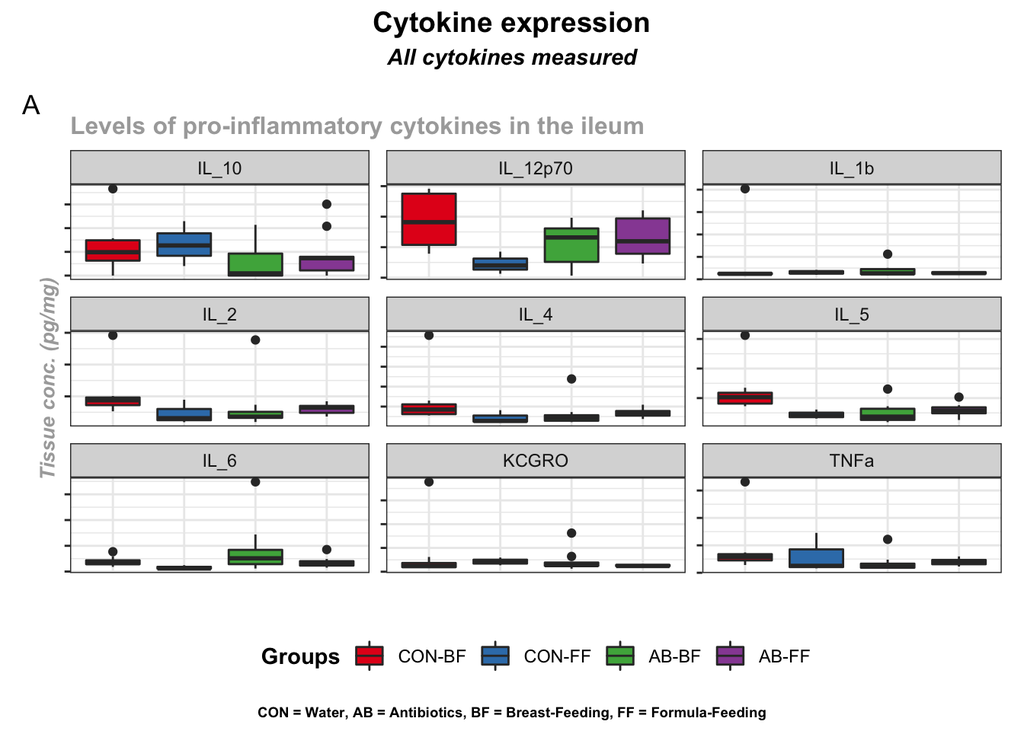

```r
plot_all_cytokines <- cytokines_long %>%
  filter(tissue == sample_tissue) %>%
  filter(!variables %in% "INFg") %>%  #Exclude any cytokines not wanted in the plot
ggplot(aes(x = group,
           y = values,
           fill = group)) +
  geom_boxplot() +
  facet_wrap(~variables,
             scales = 'free',
             nrow = 3,
             ncol = 3) +
  labs(title = "Levels of pro-inflammatory cytokines in the ileum",  # Change title, and axis names
       x = "",
       y = "Tissue conc. (pg/mg)",
       fill = "Groups") +
  theme_bw()+
  theme(                   # Change the appearance of labels
    plot.title = element_text(color="darkgrey", size=12, face="bold"),
    axis.title.y = element_text(color="darkgrey", size=10, face="bold.italic"),
    axis.text.y = element_blank(),
    axis.ticks.x = element_blank(),  # Hide labels
    axis.text.x = element_blank(),
    legend.title = element_text(face="bold"),
    legend.position="bottom",
    legend.background = element_rect(fill="white")) + # Change legend box background color
  scale_fill_brewer(palette="Set1")

all_cytokines_patch <- plot_all_cytokines + plot_annotation (
  title = 'Cytokine expression',
   subtitle = 'All cytokines measured',
  tag_levels = 'A',
  caption = 'CON = Water, AB = Antibiotics, BF = Breast-Feeding, FF = Formula-Feeding',
  theme = theme(plot.title = element_text(hjust = 0.5, size=14, face="bold"),
                plot.subtitle = element_text(hjust = 0.5, face = "bold.italic"),
                plot.caption = element_text(hjust = 0.5, size=7,face = "bold")))

all_cytokines_patch
```

```r
#ggsave('../../Results/Round 1/All Cytokines-boxplot.png',all_cytokines_patch)
```

These cytokines are plottet below:

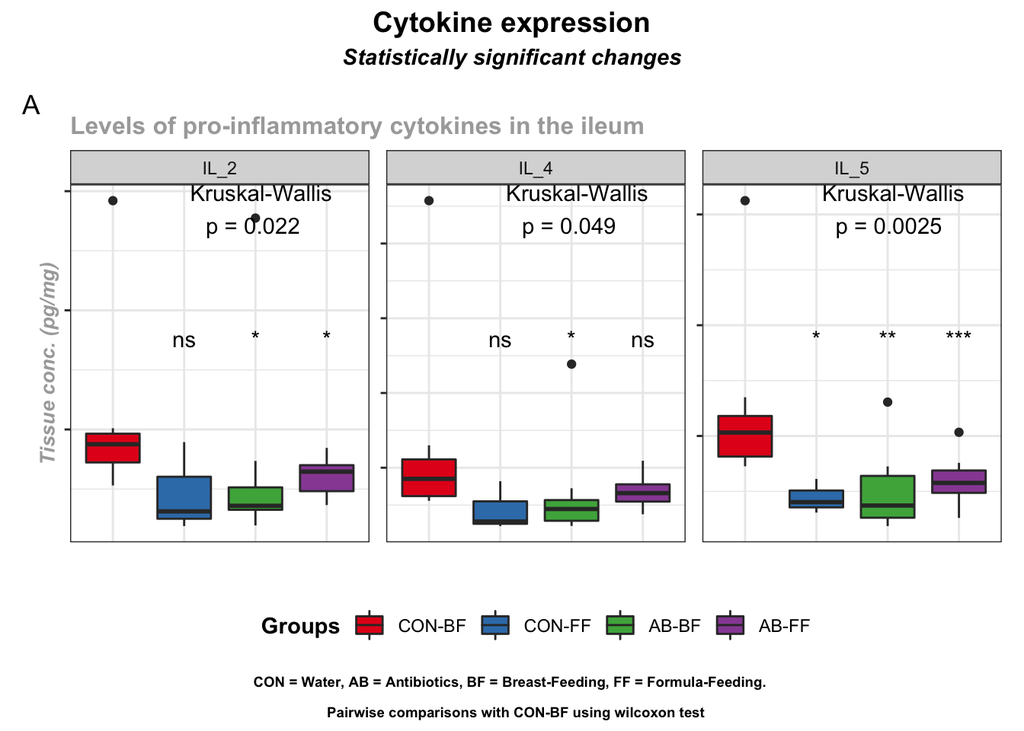

```r
#tbl1_p contains cytokines with significant changes

signif_cytokines <- cytokines_long %>%
  filter(tissue == sample_tissue) %>%
  filter(variables %in% tbl1_p$`**Groups**`) %>%  #Exclude any cytokines not wanted in the plot
ggplot(aes(x = group,
           y = values,
           fill = group)) +
  geom_boxplot() +
  stat_compare_means(aes(label = ..p.signif..),
                   method = "wilcox.test", ref.group = "CON-BF",
                   label.y.npc = 0.55) +
  stat_compare_means(
    aes(label = paste0("Kruskal-Wallis \n p = ", ..p.format..)),
    label.y.npc = 0.9,
    label.x.npc = 0.5) +
  facet_wrap(~variables,
             scales = 'free',
             nrow = 3,
             ncol = 3) +
  labs(title = "Levels of pro-inflammatory cytokines in the ileum", # Change title, and axis names
       #subtitle = "Statistically significant changes",
       x = "",
       y = "Tissue conc. (pg/mg)",
       fill = "Groups") +
  theme_bw()+
  theme(                   # Change the appearance of labels
    plot.title = element_text(color="darkgrey", size=12, face="bold"),
    axis.title.y = element_text(color="darkgrey", size=10, face="bold.italic"),
    axis.text.y = element_blank(),
    axis.ticks.x = element_blank(),  # Hide labels
    axis.text.x = element_blank(),
    legend.title = element_text(face="bold"),
    legend.position="bottom",
    legend.background = element_rect(fill="white")) + # Change legend box background color
  scale_fill_brewer(palette="Set1")

signif_cytokines_patch <- signif_cytokines + plot_annotation (
  title = 'Cytokine expression',
  subtitle = 'Statistically significant changes',
  tag_levels = 'A',
  caption = 'CON = Water, AB = Antibiotics, BF = Breast-Feeding, FF = Formula-Feeding. \n
  Pairwise comparisons with CON-BF using wilcoxon test',
  theme = theme(plot.title = element_text(hjust = 0.5, size=14, face="bold"),
                plot.subtitle = element_text(hjust = 0.5, face = "bold.italic"),
                plot.caption = element_text(hjust = 0.5, size=7,face = "bold")))
signif_cytokines_patch
```

```r
#ggsave('../../Results/Round 1/Significant Cytokines-boxplot.png',signif_cytokines_patch)
```

A regression model of the effects of type of feed and antibiotics treatment

Effect of treatment factors on cytokine expression levels

| variables | term | estimate | std.error | p.value |
| --- | --- | --- | --- | --- |
| IL_10 | MATCON | 0.060 | 0.049 | 0.237 |
| IL_10 | FEEDFF | 0.024 | 0.046 | 0.599 |
| IL_10 | MATCON:FEEDFF | -0.012 | 0.081 | 0.883 |
| IL_12p70 | MATCON | 0.759 | 0.360 | 0.045 |
| IL_12p70 | FEEDFF | 0.203 | 0.335 | 0.550 |
| IL_12p70 | MATCON:FEEDFF | -1.610 | 0.592 | 0.011 |
| IL_1b | MATCON | 0.308 | 0.359 | 0.398 |
| IL_1b | FEEDFF | -0.120 | 0.333 | 0.722 |
| IL_1b | MATCON:FEEDFF | -0.285 | 0.589 | 0.632 |
| IL_2 | MATCON | 0.075 | 0.061 | 0.236 |
| IL_2 | FEEDFF | -0.019 | 0.057 | 0.737 |
| IL_2 | MATCON:FEEDFF | -0.100 | 0.101 | 0.331 |
| IL_4 | MATCON | 0.064 | 0.040 | 0.127 |
| IL_4 | FEEDFF | 0.002 | 0.038 | 0.952 |
| IL_4 | MATCON:FEEDFF | -0.088 | 0.066 | 0.194 |
| IL_5 | MATCON | 0.147 | 0.047 | 0.004 |
| IL_5 | FEEDFF | 0.018 | 0.044 | 0.676 |
| IL_5 | MATCON:FEEDFF | -0.180 | 0.077 | 0.028 |
| IL_6 | MATCON | -2.576 | 1.504 | 0.099 |
| IL_6 | FEEDFF | -2.720 | 1.398 | 0.063 |
| IL_6 | MATCON:FEEDFF | 1.561 | 2.470 | 0.533 |
| INFg | MATCON | 0.005 | 0.015 | 0.737 |
| INFg | FEEDFF | 0.018 | 0.020 | 0.424 |
| INFg | MATCON:FEEDFF | NA | NA | NA |
| KCGRO | MATCON | 0.618 | 0.871 | 0.484 |
| KCGRO | FEEDFF | -0.525 | 0.809 | 0.522 |
| KCGRO | MATCON:FEEDFF | -0.196 | 1.430 | 0.892 |
| TNFa | MATCON | 0.255 | 0.147 | 0.096 |
| TNFa | FEEDFF | 0.011 | 0.137 | 0.937 |
| TNFa | MATCON:FEEDFF | -0.138 | 0.242 | 0.573 |